# tesshy::www

# キャンピングカー制作日誌::2019-04-14

Tetsushi Watanabe

2019-07-21 19:51

ソース

さてさて、間がだいぶ空いてしまいましたが現状報告。

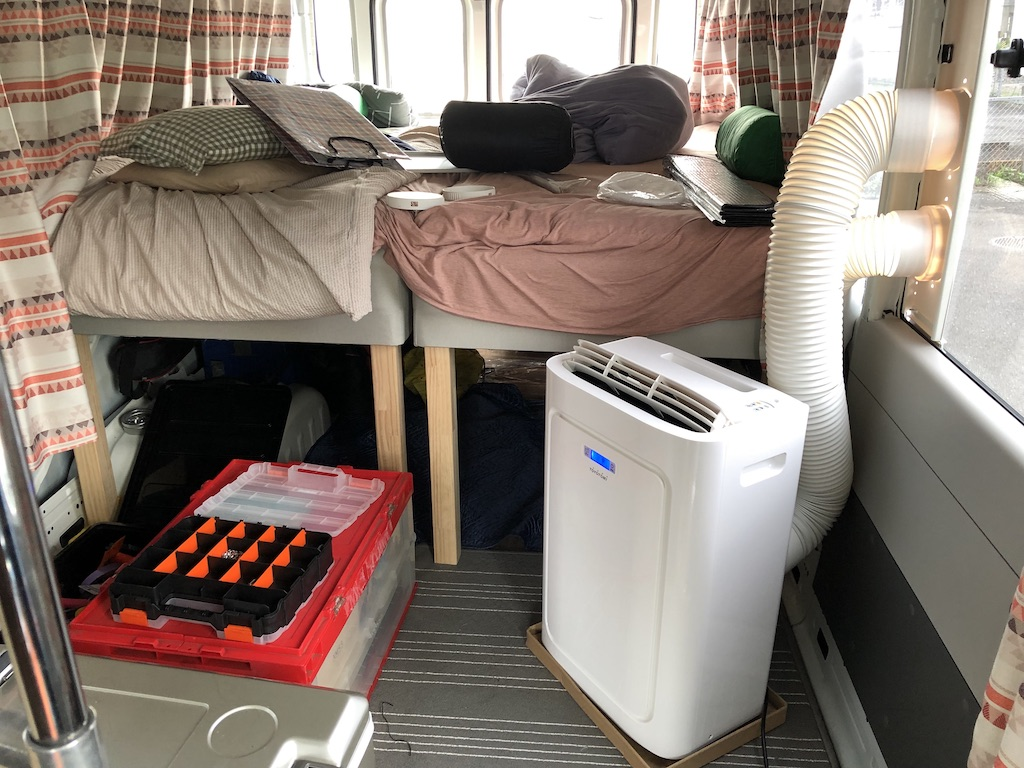

（ごっちゃごちゃだが・・・）前回の投稿時に作成した脚をつけて、IKEAの脚付きマットレスを底上げして配置完了。

脚の材質について悩んでいたんだが、結局以下のパイン集成材を使用した。

[〔パイン集成材〕 無節角材 60mm×60mm 長さ2440mm ¥3,000（税込）](https://joyfulhonda.jp/item/244313/)

これを4等分すると610mmになり丁度いい長さに。そんでもってM8 50mmのハンガーボルト打って完成。

車内に搬入する時は流石に二人がかりじゃないと無理でした。とりあえずはこれでいいんだけど、実際走ってるとズレるのでL型アングルで固定しようと思ってます。

そしてもう一点怪しい機材が。。。これ、最近の暑さと湿度に耐えかね、去年から計画はしてたクーラーを設置。だが、まだ太陽光載せたりサブバッテリー積んでないのでとりあえず外部給電で・・・。

今回チョイスしたのはトヨトミのTAD-22JW。

- http://www.toyotomi.jp/products/air-condition/spot/tad-22jw/
- https://kakaku.com/item/K0001145053/

ずっと工場とかに置いてあるスポットクーラーつけようかと思ってたんだが、デカすぎるのでこちらに。正直どうかなと思いながら使ってみたところ、それなりには冷えるので問題無し。

但し、ダクトパネルを窓に挟むのだが、これがビミョーに高さが足りない・・・。補助板半分にぶった切れば使えそうだったが、それも面倒なのでとりあえず木板でつぎはぎして設置。単純にスライド窓で挟んでるだけなので、内側から固定しようかなとは思ってる。

と、いうわけでそれなりに設備が入ってきました。が、やっぱり物置くと狭くなりますねぇ・・・。 他にサブバッテリー・太陽光関係のコントローラーと机を置かないといかんので、ちょっと設置に関しては今一度寸法計り直して再設計しようと思います。（断熱材もまだ入れてないし・・・）

ちなみにですが、どうやったら快適に寝られるかを体感するために、6月中旬から毎日バスで寝ております（家に広々ベットがあるのに・・・）。そこの体感で得られたことは。湿度が最重要だけど、その次にどうも空気の流れ（循環）がある程度ないと睡眠が浅くなるっぽい。これも不思議なもんで、エアコンが入ったから今後一週間で再度検証したいと思う。

一つだけ言えるのは、ベット、最高。最初からこうすりゃよかったとちょっと後悔しております・・・。

次回はカーテン設置について。

Share